# Coursework Report by 218204

*N* removed NAs: 2

*N* removed typo: 1

*N* removed <18: 23

*N* total clean: 124

| Group | *N* | *M*<sub>age</sub> | *M*<sub>rating</sub> |
| --- | --- | --- | --- |
| Control | 59 | 20.8 | 7.17 |
| Experim | 65 | 20.9 | 5.83 |

**Main analysis results**

*t*(122) = 10.73, *p* < .001

[interactive chart not shown]

[figure not shown]

[interactive chart not shown]

# Coursework Report by 218204

Analysing Data, Spring 2020

Friday 31th April, 2020

# Methods

## Participants

Table 1: Descriptives of Age in Each Condition

| Condition | Mean(years) | SD | Min Age | Max Age |
| --- | --- | --- | --- | --- |
| control | 20.8 | 2.27 | 18 | 26 |
| experimental | 20.9 | 2.01 | 18 | 26 |

## Design

This research was aimed at investigating the possibility of an effect of the colour red on the ratings of perceived male attractiveness by women. To do so, the effect of a red boundary on a photo was compared to that of a white boundary on the same photo. This effect was operationalised using three items; “How attractive do you think this person is?” “How pleasant is this person to look at?” and “If I were to meet the person in this picture face to face, I would think he is attractive.”. Participants were asked to respond by picking a number on a 9-point scale under each item. A score of “9” on one indicates high attractiveness, whereas a “1” would be a low attractiveness score.To test the hypothesis that the colour red will have a positive effect on attractiveness ratings, a t-test was carried out on the data.

This experiment was caried out using a between subjects design. Participants were randomly allocated to one of two experimental conditions after signing up to take part in the study. Upon allocation, each participant was sent an email containing the link to the study website. The study website included a page showing their rights to data protection and withdrawal, as well as a box for them to indicate their consent to participate. If this box was ticked, the participant was taken to a page to report their name, age, and country of origin in order to develop a unique id. After filling out this form, participants were shown the black and white picture of a man with his face blurred, placed in either a red or white frame. Under this picture would be the three items which participatns were asked to fill out. Participants in the control condition only saw the man in the white frame and, participants in the experimental condition saw the picture in a red frame. Finally, participants were thanked for their efforts and received credits for their time.

# Results

Generally, the data has shown that the red frame did have some effect on how attractive the man was perceived by the participants, however the effect was contrary to our predictions. We can see this from the mean values of the composite attractivness score in each condition. The mean value for the control group was 7.17, whereas the corresponding value for the experimental group was 5.82 (*M*<sub>diff</sub> = 1.35 , 95% CI [1.10, 1.59]). This large difference in means shows that there was indeed an effect on attractiveness. The figure below shows that with the red frame, participants recorded lower attractiveness scores on average.

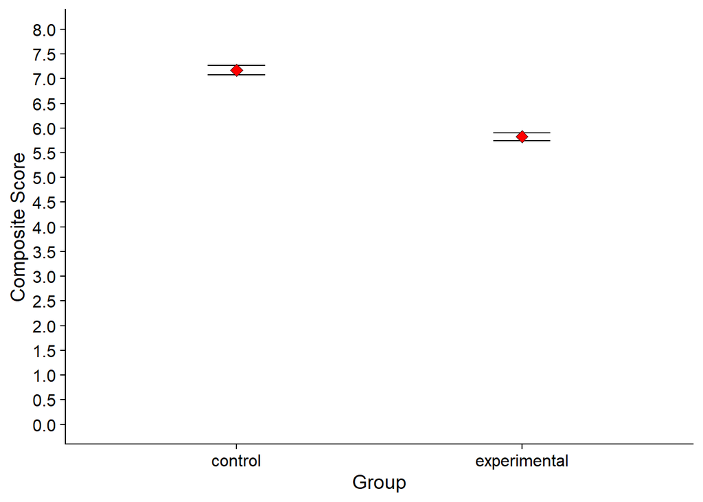

# Discussion

Many studies have investigated the correlates of the colour red in various societies. Some have found that, insome cultures, red is associated with high status. Some studies into animal culture have even found that some species of animals having a red colouration on their bodies are viewed as attractive depending on the intesity of that colouration(Marty, 2009). Other studies have investigated the relationship between the colour red and dominance(Little, 2007). This study, however, investigates the effect of the colour red on perceived attractiveness. It was found that the red accent did significantly effect attractiveness ratings. Although this study did not establish the exact relationship between the colour red and attractiveness like some previous research, it does give credence to this idea.Future researchers might benefit from looking directly into the factors that connect the colour red to attractiveness. The results from this study, however, contradict those from previous research on the relationship between red and attractiveness(Elliot, 2010). Much like the research on the red effect on human mate preferences by Peperkoorn et al(2016), this study did not find evidence supporting the red effect.

The use of a blurred picture helped to add internal validity to the study, because it means that attractiveness ratings were affected significantly by the colour of the picture frame. Ethical concerns were also taken care of by excluding data from underaged participants. However, one issue with this research is that the participants were from a university in England. The results could be therefore be seen as unrepresentative; both by age and culturally. To rectify this, future research could focus on doing these studies on several populations around England with participants of different ages. The design of this study could also have been an issue becuase each woman did not give an opinion on the picture in both conditions. To avoid this, further research could make use of a within_subjects design with counterbalancing measures in place.In addition, these reseults might have been influenced by demand characteristics. There was no follow-up during the online debrief to confirm whether participants knew the purpose of the study or not. This means that we can not be sure that participants answered the questions without any biases. Therefore, future researchers might benefit from asking participants if they knew the purpose of the study- if they decide to replicate it.

# References

Elliot, G.G. (2010). Rank, Red and Romace in Women Viewing Men.*Journal of Experimental Psychology*, 399-417.

Little, A. C. (2007). Attribution to Red Suggests Special Role in Dominance Signalling. *Journal of volutionary Psychology*, 161- 168.

Peperkoorn, L. S., Roberts, S. C., & Pollet, T. V. (2016). Revisiting the red effect on attractiveness and sexual receptivity: No effect of the color red on human mate preferences. *Evolutionary Psychology*, 14(4), 1–13.

Marty, H. G. (2009). Dominance, Coloration, and Social and Sexual Behavior in Male Drills Mandrillus leucophaeus. *International Journal of Primatology*, 807- 823.